# 4741 HW 3 Q1

## 4741, HW 3, Question 1

## Submitted by: Aman Jain (aj644)

### Part (a)

Probability that k people (at a polling station) vote for warren = $_{n}^{k}\textrm{C} * \mu^k * (1-\mu)^(n-k) $  
Given n = 10, $/mu$ = 0.05  
p = no. of polling stations,  
Lets P = Probability that at least one polling location will have ν_j = 0  
or P = 1 - (No polling location will have νj = 0$)^p$  
or P = 1 - (P(At least one per person voted in favour)$)^p$  
or P = 1 - (1 - P(k = 0)$)^p$  
or P = 1 - (1 - (1-$\mu)^n)^p$  
or P = 1 - (1 - 0.95$^n)^p$  
or P = 1 - (1 - 0.95^10)^p  
**$\mu$ = 0.05**  
for p = 1,  
P = 1 - (1 - 0.95^10)^1  
P = 0.5987  
for p = 1000,  
P = 1 - (1 - 0.95^10)^1000  
P = 1  
for p = 1,000,000  
P = 1 - (1 - 0.95^10)^1000000  
P = 1  
**$\mu$ = 0.8**  
for p = 1, and  
P = 1 - (1 - 0.2^10)^1  
P = 1.024e-07  
for p = 1000,  
P = 1 - (1 - 0.2^10)^1000  
P = 0.0001023  
for p = 1000000  
P = 1 - (1 - 0.2^10)^1000000  
P = 0.09733

```python
p = 1-pow((1 - pow(0.2,10)),1000000)
p
```

```
0.09733159268316072
```

### Part (b)

```python
from scipy.stats import binom
import matplotlib.pyplot as plt
import numpy as np
```

```python
X = [0,1,2,3,4,5,6]
Y = binom.pmf(X,6,0.5)
Y
```

```
array([0.015625, 0.09375 , 0.234375, 0.3125  , 0.234375, 0.09375 ,
       0.015625])
```

lets consider, P = $P[[|ν_1 −μ|>ε]$  
P(ε) = 2 $P[|ν_1 −0.5|>ε]$ for ε > 0  
P(ε) = 2 $P[|ν_1 >0.5 + ε]$ for ε > 0  
P(ε) = 2 *$P[|K >n*(0.5 + ε)]$ for ε > 0 <br> P(ε) = 2* $P[|K > 6(0.5 + ε)]$ for ε > 0  
P(ε) = 2 $P[|K > 3 + 6ε)]$ for ε > 0

Coming back to P(ε):  
P(ε) = 2 $P[|K > 3 + 6ε)]$ for ε > 0  
P(ε = 0) = 2$P[|K > 3)]$ = 2 P[K = 4,5,6] = 0.6875  
P(ε = 0.05) = 2$P[|K > 3+0.3)]$ = 2*$P[|K > 3.3)]$ = 2* P[K = 4,5,6] = 0.6875  
P(ε = 0.1) = 2*$P[|K > 3+0.6)]$ = 2*$P[|K > 3.6)]$ = 2 P[K = 4,5,6] = 0.6875  
P(ε = 0.15) = 2$P[|K > 3+0.9)]$ = 2*$P[|K > 3.9)]$ = 2* P[K = 4,5,6] = 0.6875  
P(ε = 0.2) = 2*$P[|K > 3+1.2)]$ = 2*$P[|K > 4.2)]$ = 2 P[K = 5,6] = 0.21875  
P(ε = 0.25) = 2$P[|K > 3+1.5)]$ = 2*$P[|K > 4.5)]$ = 2* P[K = 5,6] = 0.21875  
P(ε = 0.3) = 2*$P[|K > 3+1.8)]$ = 2*$P[|K > 4.8)]$ = 2 P[K = 5,6] = 0.21875  
P(ε = 0.35) = 2$P[|K > 3+2.1)]$ = 2*$P[|K > 5.1)]$ = 2* P[K = 6] = 0.03125  
P(ε = 0.4) = 2*$P[|K > 3+2.4)]$ = 2*$P[|K > 5.4)]$ = 2 P[K = 6] = 0.03125  
P(ε = 0.45) = 2$P[|K > 3+2.7)]$ = 2*$P[|K > 5.7)]$ = 2* P[K = 6] = 0.03125  
P(ε = 0.5) = 2*$P[|K > 3+3)]$ = 2*$P[|K > 6)]$ = 2* 0 = 0  
P(ε > 0.5) = 0

```python
a = 0.015625
2*a
```

```
0.03125
```

```python
b = 0.03125
2*b - pow(b,2)
```

```
0.0615234375
```

```python
h = np.linspace(0,1,21)
h
```

```
array([0.  , 0.05, 0.1 , 0.15, 0.2 , 0.25, 0.3 , 0.35, 0.4 , 0.45, 0.5 ,
       0.55, 0.6 , 0.65, 0.7 , 0.75, 0.8 , 0.85, 0.9 , 0.95, 1.  ])
```

```python
P = [0.6875, 0.6875 ,0.6875 ,0.6875 ,0.21875, 0.21875, 0.21875, 0.03125 ,0.03125 ,0.03125 , 0,0,0,0,0,0,0,0,0,0,0]
np.size(P)
```

```
21
```

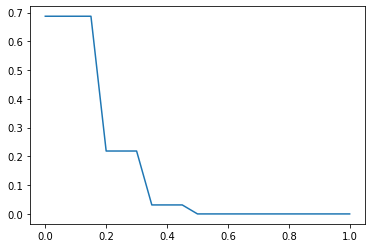

```python
plt.plot(h,P)
```

using Hoeffding Inequality, P[|ν − μ| > ε] ≤ 2e−2nε2,

```python
P_hoeff = 2*np.exp(-2*6*pow(h,2))
```

```python
P_hoeff
```

```
array([2.00000000e+00, 1.94089107e+00, 1.77384087e+00, 1.52675899e+00,
       1.23756678e+00, 9.44733105e-01, 6.79191051e-01, 4.59850970e-01,
       2.93213924e-01, 1.76073665e-01, 9.95741367e-02, 5.30323688e-02,
       2.65997671e-02, 1.25648403e-02, 5.58957055e-03, 2.34175924e-03,
       9.23949798e-04, 3.43318208e-04, 1.20140001e-04, 3.95932139e-05,
       1.22884247e-05])
```

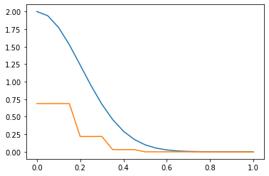

```python
plt.plot(h,P_hoeff)
plt.plot(h,P)
```

Now lets consider two centers:  
Required probability, G(ε) = $P[max|ν_j −μ|>ε]$  
Required probability, G(ε) = $P((|ν_1 −μ|$ AND $|ν_2 −μ|) > ε)$  
Required probability, G(ε) = $P(|ν_1 −μ| > ε )$ + P$(|ν_2 −μ| > ε)$ - $P(|ν_1 −μ| > ε)*(|ν_2 −μ| > ε)) >0)$  
Required probability, G(ε) = P(ε) + P(ε) - P(ε)* P(ε)  
Required probability, G(ε) = 2P(ε) - (P(ε))^2

Required probability, G(ε) = 2P(ε) - (P(ε))^2  
G(ε = 0) = 2 * 0.6875 - (0.6875)^2 = 0.90234375  
G(ε = 0.05) = 0.90234375  
G(ε = 0.1) = 0.90234375  
G(ε = 0.15) = 0.90234375  
G(ε = 0.2) = 0.3896484375  
G(ε = 0.25) = 0.3896484375  
G(ε = 0.3) = 0.3896484375  
G(ε = 0.35) = 0.0615234375  
G(ε = 0.4) = 0.0615234375  
G(ε = 0.45) = 0.0615234375  
G(ε = 0.5) = 0  
G(ε > 0.5) = 0

```python
G = [0.90234375, 0.90234375 ,0.90234375 ,0.90234375 , 0.3896484375, 0.3896484375, 0.3896484375, 0.0615234375 ,0.0615234375 ,0.0615234375 , 0,0,0,0,0,0,0,0,0,0,0]
np.size(G)
```

```
21
```

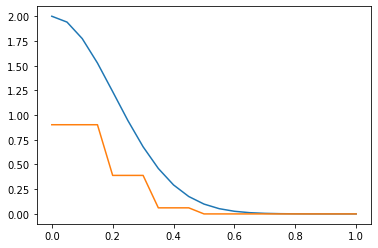

```python
plt.plot(h,P_hoeff)
plt.plot(h,G)
```